# t-Tests

Randomisierung vs. traditionelle Methodik

Prof. Dr. Jörg Schoder

2025-04-03

# Einführung

Liegen Daten zu Merkmalen auf **metrischer Skala** vor, interessieren häufig **Vergleiche von Mittelwerten**. In der *traditionellen Statistik* werden Mittelwertsunterschieden zwischen einer oder mehreren Stichproben dabei mit sog. t-Tests überprüft. Diese Tests sind essenziell für viele wissenschaftliche Untersuchungen und finden Anwendung in Bereichen wie Medizin, Psychologie und Wirtschaftsforschung.

Nach der Struktur des betrachteten Problems werden in der Regel **drei Fälle** unterschieden:

1. Einstichproben-t-Test: Prüft, ob der Mittelwert einer Stichprobe von einem bekannten oder theoretischen Wert abweicht.
2. Zweistichproben-t-Tests…
   - …mit abhängigen Stichproben: Wird verwendet, wenn Messwerte paarweise zusammenhängen, z. B. bei Vorher-Nachher-Messungen.
   - …mit unabhängigen Stichproben: Vergleicht die Mittelwerte zweier unabhängiger Gruppen, um festzustellen, ob sie sich signifikant unterscheiden.

Im folgenden werden Beispiele für Mittelwert-Tests für diese drei Fälle betrachtet. Die Tests erfolgen dabei zum einen mittels Randomisierung (moderner, nichtparametrischer Ansatz) und zum anderen mit Annahmen über theoretische Verteilungen (traditioneller, parametrischer Ansatz).

# Eine Stichprobe

## Daten

```r
library(tidyverse)
library(glue)
library(gt)
# Beispiel GSS Wochenarbeitszeit ----
library(infer)
tbl_gss <- gss

library(moderndive)
## Mittelwert in den Daten ----
m_hours <- tbl_gss %>%
              summarise(m_hours=mean(hours))
m_hours
```

```
## # A tibble: 1 × 1
##   m_hours
##     <dbl>
## 1    41.4
```

## Deskriptive Statistik

```r
## Annahme zum Erwartungswert ----
E_hours<-40 #Annahme über den "wahren" Erwartungswert der wöchentl. Arbeitszeit
```

```r
## Modell spezifizieren und Annahmen treffen -----
tbl_gss %>%
  specify(response = hours) %>% # betrachtete Variable(n) festlegen
  hypothesize(null = "point", mu = E_hours) #Annahme treffen
```

```
## Response: hours (numeric)
## Null Hypothesis: point
## # A tibble: 500 × 1
##    hours
##    <dbl>
##  1    50
##  2    31
##  3    40
##  4    40
##  5    40
##  6    53
##  7    32
##  8    20
##  9    40
## 10    40
## # ℹ 490 more rows
```

## Test mittels Randomisierung/Resampling

```r
## Zufallsstichproben erzeugen -----
set.seed(23) # für reproduzierbare Ergebnisse
tbl_gss %>%
  specify(response = hours) %>%
  hypothesize(null = "point", mu = E_hours) %>%
  generate(reps = 1000, type = "bootstrap")  # Zufallsstichproben mit bootstrap
```

```
## Response: hours (numeric)
## Null Hypothesis: point
## # A tibble: 500,000 × 2
## # Groups:   replicate [1,000]
##    replicate hours
##        <int> <dbl>
##  1         1  54.6
##  2         1  58.6
##  3         1  28.6
##  4         1  38.6
##  5         1  86.6
##  6         1  38.6
##  7         1  25.6
##  8         1  38.6
##  9         1  48.6
## 10         1  38.6
## # ℹ 499,990 more rows
```

```r
## Stichprobenverteilung -----
### Ermittlung mit calculate -----
set.seed(23) # für reproduzierbare Ergebnisse
null_dist <- tbl_gss %>%  # speichern im Objekt null_dist
  specify(response = hours) %>%
  hypothesize(null = "point", mu = E_hours) %>%
  generate(reps = 1000, type = "bootstrap") %>%
  calculate(stat = "mean")

null_dist
```

```
## Response: hours (numeric)
## Null Hypothesis: point
## # A tibble: 1,000 × 2
##    replicate  stat
##        <int> <dbl>
##  1         1  38.8
##  2         2  39.0
##  3         3  39.5
##  4         4  40.2
##  5         5  39.5
##  6         6  39.6
##  7         7  41.2
##  8         8  39.5
##  9         9  39.4
## 10        10  39.3
## # ℹ 990 more rows
```

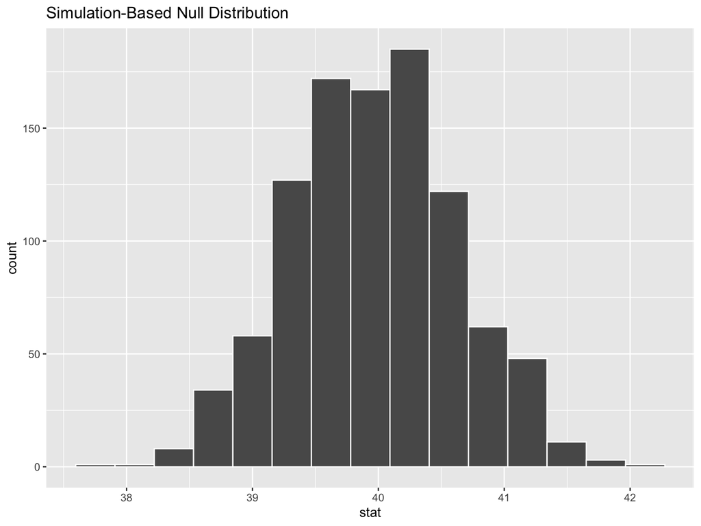

```r
### Dataviz ----
#### einfacher Plot ----
null_dist %>%
  visualize()
```

```r
## p-Wert ermitteln -----
p_value <- null_dist %>%
                get_p_value(obs_stat = m_hours, direction = "two-sided")

p_value
```

```
## # A tibble: 1 × 1
##   p_value
##     <dbl>
## 1   0.024
```

```r
p_value_percent <- glue(100*as.numeric(p_value),"%")
```

```r
## Konfidenzintervall -----
### Bootstrapping-Verteilung erzeugen -----
# Im Unterschied zur Null-Verteilung wird hier auf die Annahme (Nullhypothese) verzichtet!
boot_dist <- tbl_gss %>%
                specify(response = hours) %>% #Obs! hypothesize() fehlt
                generate(reps = 1000, type = "bootstrap") %>%
                calculate(stat = "mean")
### Konfidenzintervall berechnen -----

ci <- boot_dist %>% # Ausgangspunkt bootstrap-Verteilung

          get_confidence_interval(point_estimate = m_hours,# Berechnung des KI um den Mittelwert der GSS-Daten (Stichprobenmittelwert)
                          level = .95,# Festlegung: 95% Konfidenzniveau
                          type = "se") # Methode: Standardfehler (standard error)
ci
```

```
## # A tibble: 1 × 2
##   lower_ci upper_ci
##      <dbl>    <dbl>
## 1     40.1     42.7
```

Grafisch

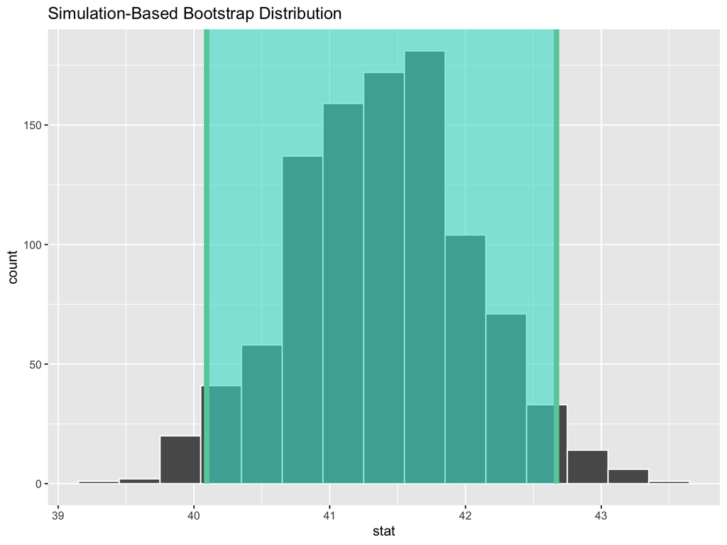

```r
### Dataviz-----
boot_dist %>%
  visualize() +
  shade_confidence_interval(endpoints = ci)
```

## Traditioneller t-Test

Wie erwähnt handelt es sich bei den traditionellen Tests um parametrische Verfahren, die auf bestimmten Annahmen basieren. Nur wenn diese Annahmen erfüllt sind, können die Ergebnisse des Tests als valide gelten.

### Annahmen prüfen

Eine zentrale Voraussetzung für die Anwendbarkeit eins t-Tests ist die Normalverteilung der Daten, die zumindest annähernd gegeben sein muss, damit die Testergebnisse valide sind.

Die Annahme der Normalverteilung kann häufig bereits durch Visualisierung der Daten beurteilt werden:

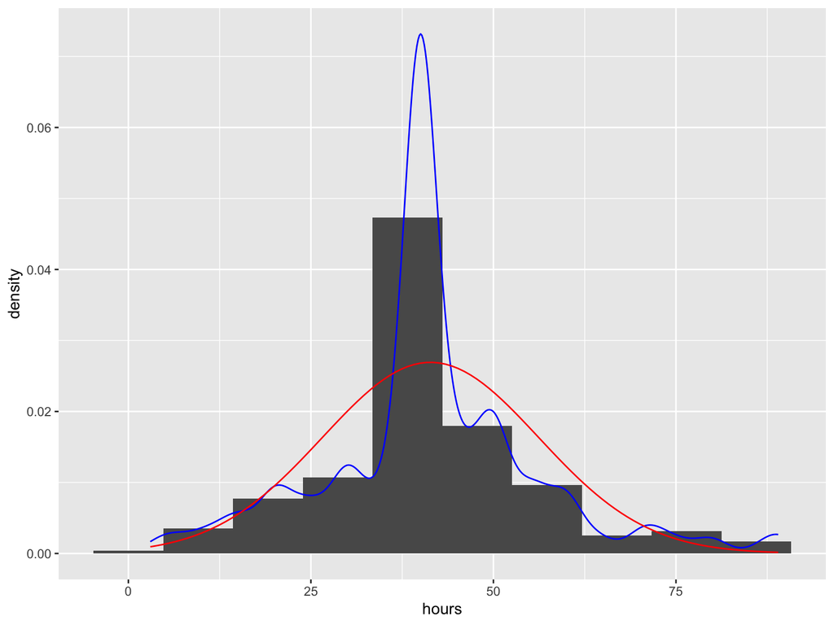

```r
# Histogramm mit Normalverteilungskurve
tbl_gss %>%
  ggplot(aes(x=hours)) +
    geom_histogram(aes(y = after_stat(density)),bins=10) +
    geom_density(stat="density", color='blue') +
    stat_function(fun = dnorm, args = list(mean = mean(tbl_gss$hours), sd = sd(tbl_gss$hours)),color='red')
```

Dem Augenschein nach ist die Verteilung zwar symmetrisch, wirkt aber verglichen mit der Normalverteilung (rot) sehr spitz. Entsprechend ist nicht von einer Normalverteilung auszugehen.

Mit dem Shapiro-Wilk-Test kann diese optische Einschätzung noch objektiviert werden.

```r
# Shapiro-Wilk-Test auf Normalverteilung
tbl_gss %>%
  select(hours) %>%
  pull() %>%
  shapiro.test()
```

```
##
##  Shapiro-Wilk normality test
##
## data:  .
## W = 0.93151, p-value = 2.323e-14
```

Der Shapiro-Wilk-Test bestätigt die optische Beurteilung: Auf dem 5%-Signifikanzniveau ist die Annahme der Normalverteilung zu verwerfen.

Mithin erübrigt sich eigentlich die Durchführung des t-Tests, was zeigt, dass die modernen Verfahren des Resamplings deutliche Vorteile im Vergleich zu den traditionellen Verfahren haben.

Im folgenden soll der t-Test dennoch durchgeführt werden, um die grundsätzliche Vorgehensweise bei einem traditionellen Test zu illustrieren.

### Exkurs: t-Verteilung

Wäre die wahre Standardabweichung bekannt, so wäre die normierte Abweichung des Mittelwerts unter der Annahme der Normalverteilung von X ebenfalls normalverteilt:
$$Z=\frac{\bar{X}-\mu_0}{\sigma}\sim
N$$
Weil jedoch in der Regel die wahre Standardabweichung unbekannt ist, liegt es nahe, diese mit der empirischen Standardabweichung $s$ zu *schätzen*. Die entsprechende standardisierte Schätzfunktion des Stichproben-Mittelwerts normalverteilter Daten ist dann jedoch nicht mehr normalverteilt, sondern t-verteilt:

$$T=\frac{\bar{X}-\mu_0}{s}$$

### R als Taschenrechner

Ermittlung der T-Statistik:

```r
# Traditionelle Tests-----
## t-Test -----
### Teststatistik ermitteln ----
#### R als Taschenrechner -----
T <- tbl_gss %>%
         summarise(T=(mean(hours)-40)/(sd(hours)/sqrt(n())))
T
```

```
## # A tibble: 1 × 1
##       T
##   <dbl>
## 1  2.09
```

### Nutzung der t_test()-Funktion

Natürlich besteht in R auch die Möglichkeit, die Teststatistik direkt mit speziellen Funktionen zu ermitteln. Das in jeder R-Session automatisch geladene **stats**-Paket stellt die Funktion `t.test()` zur Verfügung. Weil der Output dieser Funktion kein *tibble*-Objekt ist, empfiehlt sich aber die Verwendung der `t_test()`-Funktion aus dem **infer**-Paket, die sich nahtlos in tidy-workflows einbinden lässt.

```r
#### t_test()-Funktion
tbl_gss %>%
    t_test(response=hours, mu=40) %>%
    gt()
```

| statistic | t_df | p_value | alternative | estimate | lower_ci | upper_ci |
| --- | --- | --- | --- | --- | --- | --- |
| 2.085191 | 499 | 0.03755959 | two.sided | 41.382 | 40.07984 | 42.68416 |

# Zwei Stichproben

## Unabhängiger Fall

### Daten

```r
tbl_cities <- read_delim(xfun::from_root("data","tidy","CleSac.txt"),show_col_types = FALSE)
tbl_cities <- tbl_cities %>%
                    rename(metro_area = Metropolitan_area_Detailed,
                           income = Total_personal_income) %>%
                           na.omit()
```

### Deskriptive Statistik

```r
inc_summ <- tbl_cities %>%
                group_by(metro_area) %>%
                summarize(sample_size = n(),
                  mean = mean(income),
                  sd = sd(income),
                  minimum = min(income),
                  lower_quartile = quantile(income, 0.25),
                  median = median(income),
                  upper_quartile = quantile(income, 0.75),
                  max = max(income))

inc_summ %>%
        gt()
```

| metro_area | sample_size | mean | sd | minimum | lower_quartile | median | upper_quartile | max |
| --- | --- | --- | --- | --- | --- | --- | --- | --- |
| Cleveland_ OH | 212 | 27467.07 | 27680.68 | 0 | 8475 | 21000 | 35275 | 152400 |
| Sacramento_ CA | 175 | 32427.54 | 35773.63 | 0 | 8050 | 20000 | 49350 | 206900 |

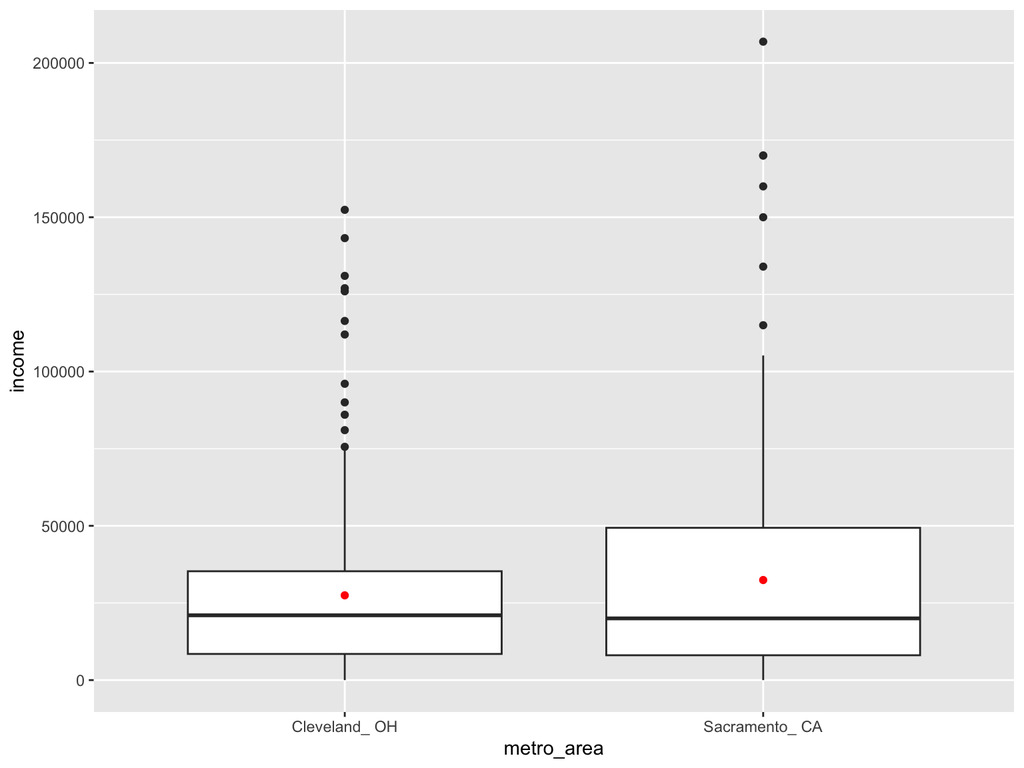

```r
tbl_cities %>% ggplot(aes(x = metro_area, y = income)) +
                geom_boxplot() +
                stat_summary(fun = mean, geom = "point", color = "red")
```

```r
observed_statistic <- tbl_cities %>%
                           specify(income ~ metro_area) %>%
  calculate(stat = "diff in means", order = c("Sacramento_ CA", "Cleveland_ OH"))

observed_statistic
```

```
## Response: income (numeric)
## Explanatory: metro_area (factor)
## # A tibble: 1 × 1
##    stat
##   <dbl>
## 1 4960.
```

### Test mittels Randomisierung/Resampling

```r
set.seed(23)
# generate the null distribution with randomization
null_dist_2_sample <- tbl_cities %>%
                          specify(income ~ metro_area) %>%
                          hypothesize(null = "independence") %>%
                          generate(reps = 1000, type = "permute") %>%
                          calculate(stat = "diff in means", order = c("Sacramento_ CA", "Cleveland_ OH"))
null_dist_2_sample
```

```
## Response: income (numeric)
## Explanatory: metro_area (factor)
## Null Hypothesis: independence
## # A tibble: 1,000 × 2
##    replicate   stat
##        <int>  <dbl>
##  1         1  1587.
##  2         2 -4155.
##  3         3 -2723.
##  4         4 -6663.
##  5         5 -1817.
##  6         6   128.
##  7         7  -768.
##  8         8 -1337.
##  9         9 -3406.
## 10        10 -3023.
## # ℹ 990 more rows
```

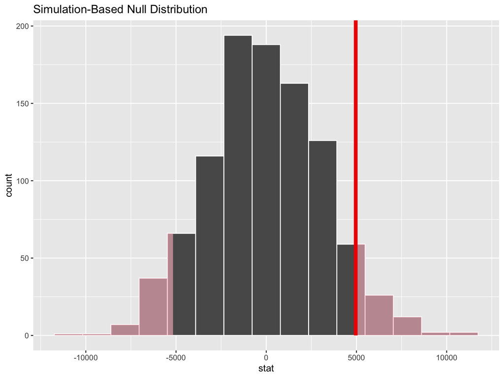

```r
null_dist_2_sample %>%
  visualize() +
  shade_p_value(observed_statistic,
                direction = "two-sided")
```

```r
# calculate the p value from the randomization-based null
# distribution and the observed statistic
p_value_2_sample <- null_dist_2_sample %>%
  get_p_value(obs_stat = observed_statistic,
              direction = "two-sided")

p_value_2_sample
```

```
## # A tibble: 1 × 1
##   p_value
##     <dbl>
## 1    0.11
```

### Tradioneller t-Test (unabhängige Stichproben)

```r
tbl_cities %>% t_test(formula = income ~ metro_area,
       order = c("Sacramento_ CA", "Cleveland_ OH"),
       alternative = "two-sided")
```

```
## # A tibble: 1 × 7
##   statistic  t_df p_value alternative estimate lower_ci upper_ci
##       <dbl> <dbl>   <dbl> <chr>          <dbl>    <dbl>    <dbl>
## 1      1.50  323.   0.134 two.sided      4960.   -1543.   11464.
```

## Abhängig

### Daten

```r
zinc_tidy <- read_csv(xfun::from_root("data","tidy","zinc_tidy.csv"),show_col_types = FALSE)

zinc_tidy <- zinc_tidy %>%
  mutate(loc_id = as.factor(loc_id))

zinc_wide <- zinc_tidy %>%
              pivot_wider(names_from = location,values_from = concentration)

zinc_paired <- zinc_wide %>%
                   mutate(diff=surface-bottom)
```

### Deskriptive Statistik

```r
library(infer)
observed_statistic <-  zinc_paired %>%
                          specify(response = diff) %>%
                          calculate(stat = "mean")
observed_statistic
```

```
## Response: diff (numeric)
## # A tibble: 1 × 1
##      stat
##     <dbl>
## 1 -0.0804
```

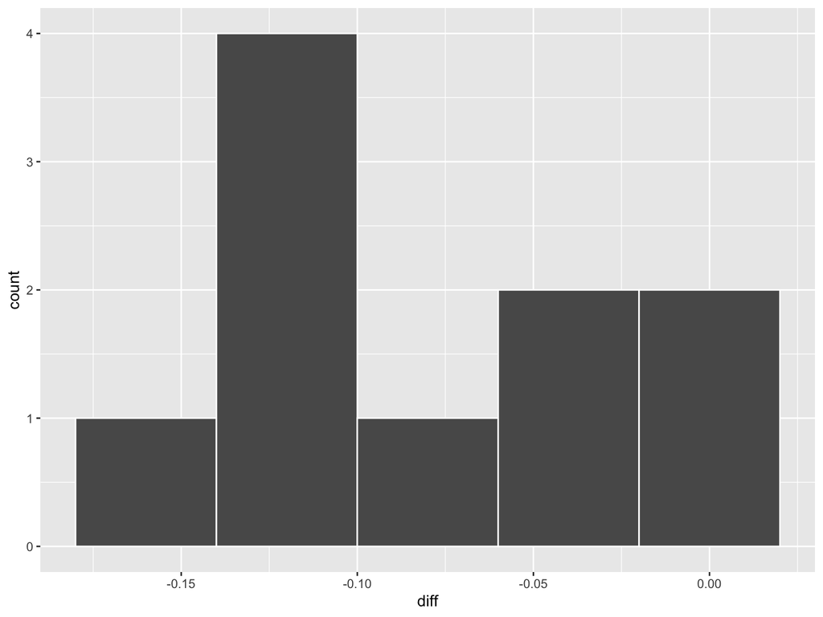

```r
zinc_paired %>% ggplot(aes(x = diff)) +
                    geom_histogram(binwidth = 0.04, color = "white")
```

### Test mittels Randomisierung/Resampling

```r
set.seed(23)
null_dist <- zinc_paired %>%
   specify(response = diff) %>%
   hypothesize(null = "paired independence") %>%
   generate(reps = 1000, type = "permute") %>%
   calculate(stat = "mean")
null_dist
```

```
## Response: diff (numeric)
## Null Hypothesis: paired independence
## # A tibble: 1,000 × 2
##    replicate      stat
##        <int>     <dbl>
##  1         1  0.0180
##  2         2 -0.000600
##  3         3  0.00740
##  4         4 -0.0312
##  5         5  0.0108
##  6         6  0.0168
##  7         7 -0.00960
##  8         8  0.0254
##  9         9  0.0158
## 10        10 -0.00380
## # ℹ 990 more rows
```

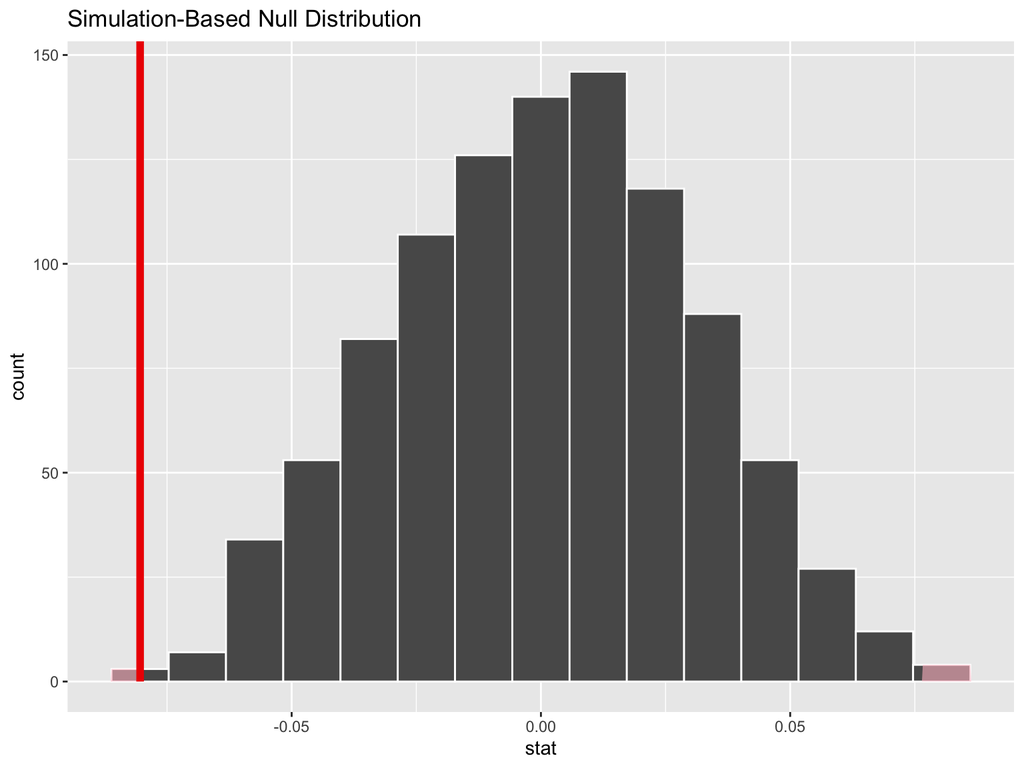

```r
null_dist %>%
  visualize() +
  shade_p_value(observed_statistic,
                direction = "two-sided")
```

```r
null_dist %>% get_p_value(obs_stat = observed_statistic,
                            direction = "two-sided")
```

```
## # A tibble: 1 × 1
##   p_value
##     <dbl>
## 1   0.004
```

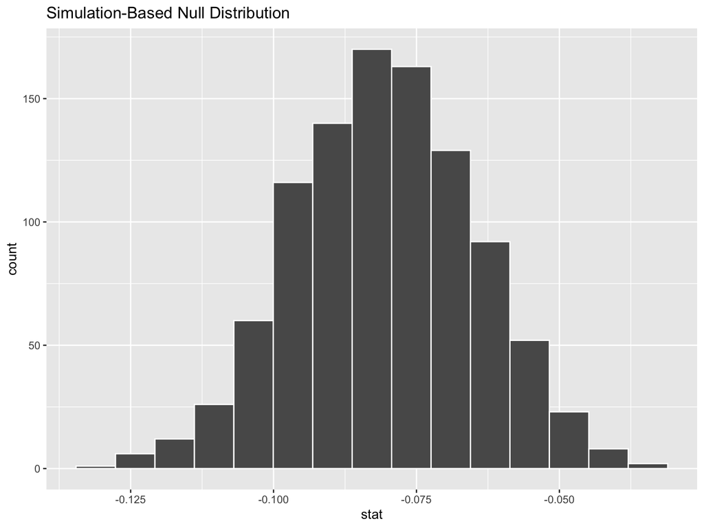

```r
boot_dist <- zinc_paired %>%
                 specify(response = diff) %>%
                 hypothesize(null = "paired independence") %>%
                 generate(reps = 1000, type = "bootstrap") %>%
                 calculate(stat = "mean")

visualize(boot_dist)
```

```r
confidence_interval <- boot_dist %>%
                           get_confidence_interval(level = .95)

confidence_interval
```

```
## # A tibble: 1 × 2
##   lower_ci upper_ci
##      <dbl>    <dbl>
## 1   -0.112  -0.0500
```

```r
confidence_interval <- boot_dist %>%
                           get_confidence_interval(type="se",
                                                   point_estimate = observed_statistic,
                                                   level = .95)

confidence_interval
```

```
## # A tibble: 1 × 2
##   lower_ci upper_ci
##      <dbl>    <dbl>
## 1   -0.111  -0.0495
```

### Traditionell

```r
stats::t.test(x = zinc_paired$diff,
       alternative = "less",
       mu = 0)
```

```
##
##  One Sample t-test
##
## data:  zinc_paired$diff
## t = -4.8638, df = 9, p-value = 0.0004456
## alternative hypothesis: true mean is less than 0
## 95 percent confidence interval:
##        -Inf -0.0500982
## sample estimates:
## mean of x
##   -0.0804
```

```r
pt(-5, df = nrow(zinc_paired) - 1, lower.tail = TRUE)
```

```
## [1] 0.000369484
```